# Rebel Origins

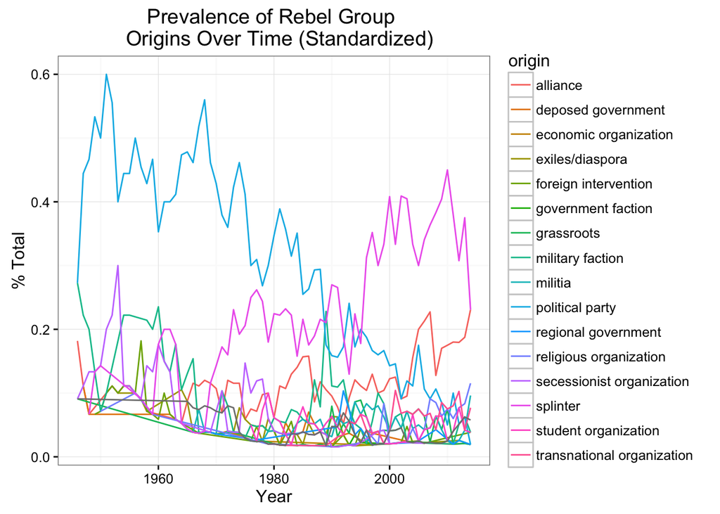

```r
ggplot(ts, aes(x=Year, y=count/tot, color=origin)) + geom_line() + theme_bw() + ylab("% Total") + ggtitle("Prevalence of Rebel Group \n  Origins Over Time (Standardized)")
```

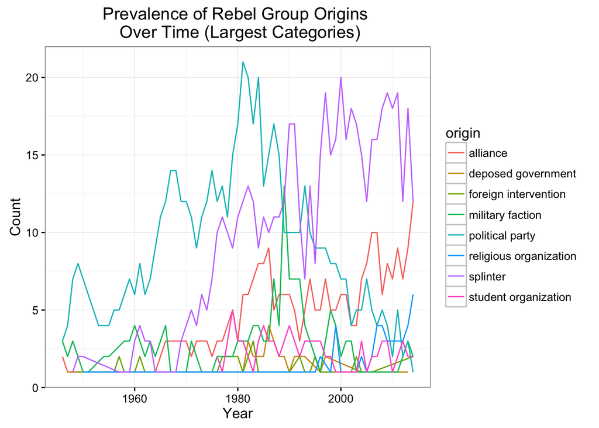

```r
sub <- dyad %>%
  group_by(origin) %>%
  mutate(type.total=n_distinct(SideBID))

sub <- subset(sub, type.total > 14) %>%
  group_by(Year, origin) %>%
  summarize(count=length(SideBID))

sub <- sub %>%
  group_by(Year) %>%
  mutate(tot=sum(count))

ggplot(sub, aes(x=Year, y=count, color=origin)) + geom_line() + theme_bw() + ylab("Count") + ggtitle("Prevalence of Rebel Group Origins \n Over Time (Largest Categories)")
```

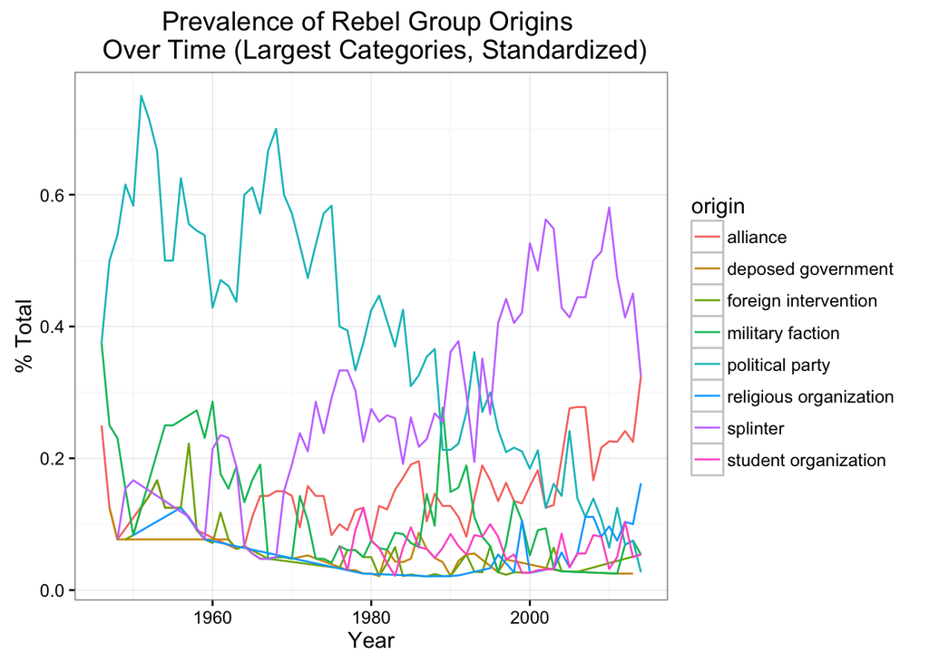

```r
ggplot(sub, aes(x=Year, y=count/tot, color=origin)) + geom_line() + theme_bw() + ylab("% Total") + ggtitle("Prevalence of Rebel Group Origins \n Over Time (Largest Categories, Standardized)")
```

```r
rm(ts,sub)
```

# Co-Occurrences

To understand what sorts processes lead to multiple rebellions, I examine patterns of co-occurrence. First I break the UCDP conflicts into episodes - a conflict year is the start of a new episode if at least two calendar years have passed since UCDP last registered a conflict.

```r
# Code Episodes if inactive for 2+ calendar years
conflict.years <- dyad %>%
  group_by(ConflictId,Year) %>%
  summarize()
#calculate gap since last year with 25+ fatalities
conflict.years <- conflict.years %>%
  group_by(ConflictId) %>%
  mutate(lag.year=lag(Year),start=min(Year))
#code a new episode if there are 2 calendar years without fighting, and for first year
conflict.years$new.ep <- ifelse(conflict.years$Year==conflict.years$start | conflict.years$Year - conflict.years$lag.year > 2, 1, 0)
#create episode numbers
conflict.years <- conflict.years %>%
  group_by(ConflictId) %>%
  mutate(epnum=cumsum(new.ep))
#create conflict episode identifier
conflict.years$ConflictEpisode <- as.factor(paste(sapply(strsplit(as.character(conflict.years$ConflictId), "-"), "[", 2),conflict.years$epnum, sep="-"))
#remove unneeded variables and merge back into full data
conflict.years <- subset(conflict.years,select=-c(lag.year,start))
dyad <- merge(dyad,conflict.years,all=T)
rm(conflict.years)

#count rebel groups active in conflict year and episode, intensity
dyad <- dyad %>%
  group_by(ConflictId, Year) %>%
  mutate(rebs.year=n_distinct(SideBID), maxint.year=max(IntensityLevel))

dyad <- dyad %>%
  group_by(ConflictEpisode) %>%
  mutate(rebs.ep=n_distinct(SideBID), maxint.ep=max(IntensityLevel))
```

## 1. What type of group is most likely to be in a multi-rebel conflict?

```r
library(knitr)

type <- dyad %>%
  group_by(ConflictId, Year) %>%
  mutate(dyads=n_distinct(SideBID))

type <- type %>%
  group_by(SideBID) %>%
  summarize(origin=first(origin), max.dyads=max(dyads))

type <- type %>%
  group_by(origin) %>%
  summarize(tot=n_distinct(SideBID), multi=sum(max.dyads>1))

type$pcmulti <- type$multi / type$tot * 100

type <- type[order(type$pcmulti, decreasing = T), ]

kable(type, col.names = c("Group Type", "Total", "In Multi-Rebel Conflict", "%"), caption = "% of Group Type involved in Multi-Rebel Conflicts")
```

% of Group Type involved in Multi-Rebel Conflicts

| Group Type | Total | In Multi-Rebel Conflict | % |
| --- | --- | --- | --- |
| militia | 13 | 9 | 69.23077 |
| economic organization | 3 | 2 | 66.66667 |
| transnational organization | 9 | 6 | 66.66667 |
| splinter | 112 | 74 | 66.07143 |
| deposed government | 17 | 11 | 64.70588 |
| alliance | 53 | 33 | 62.26415 |
| exiles/diaspora | 10 | 6 | 60.00000 |
| religious organization | 18 | 10 | 55.55556 |
| political party | 90 | 44 | 48.88889 |
| student organization | 15 | 7 | 46.66667 |
| NA | 11 | 5 | 45.45455 |
| secessionist organization | 14 | 5 | 35.71429 |
| military faction | 76 | 27 | 35.52632 |
| foreign intervention | 15 | 5 | 33.33333 |
| regional government | 12 | 3 | 25.00000 |
| grassroots | 11 | 2 | 18.18182 |
| government faction | 6 | 1 | 16.66667 |

```r
rm(type)
```

We find that some of the rarest types of organizations are the most likely to be involved in multi-rebel conflicts. Many of these make sense. Militias tend to exist for self-defense purposes, and it is perhaps not surprising that they would become involved in large conflicts. Splinters are also very likely to be involved in multi-rebel conflicts, which makes a great deal of sense.

```r
type <- subset(dyad, maxint.year==2) %>%
  group_by(ConflictId, Year) %>%
  mutate(dyads=n_distinct(SideBID))

type <- type %>%
  group_by(SideBID) %>%
  summarize(origin=first(origin), max.dyads=max(dyads))

type <- type %>%
  group_by(origin) %>%
  summarize(tot=n_distinct(SideBID), multi=sum(max.dyads>1))

type$pcmulti <- type$multi / type$tot * 100

type <- type[order(type$pcmulti, decreasing = T), ]

kable(type, col.names = c("Group Type", "Total", "In Multi-Rebel Conflict", "%"), caption = "% of Group Type involved in Multi-rebel Conflicts, Wars Only")
```

% of Group Type involved in Multi-rebel Conflicts, Wars Only

| Group Type | Total | In Multi-Rebel Conflict | % |
| --- | --- | --- | --- |
| economic organization | 1 | 1 | 100.00000 |
| transnational organization | 6 | 5 | 83.33333 |
| religious organization | 11 | 9 | 81.81818 |
| splinter | 33 | 26 | 78.78788 |
| alliance | 23 | 18 | 78.26087 |
| militia | 4 | 3 | 75.00000 |
| grassroots | 3 | 2 | 66.66667 |
| political party | 39 | 23 | 58.97436 |
| military faction | 19 | 11 | 57.89474 |
| foreign intervention | 4 | 2 | 50.00000 |
| student organization | 4 | 2 | 50.00000 |
| NA | 5 | 2 | 40.00000 |
| secessionist organization | 8 | 3 | 37.50000 |
| exiles/diaspora | 6 | 2 | 33.33333 |
| regional government | 6 | 2 | 33.33333 |
| deposed government | 7 | 2 | 28.57143 |
| government faction | 1 | 0 | 0.00000 |

```r
rm(type)
```

## 2. What kinds of groups are most common in multi-rebel conflict years?

```r
years <- subset(dyad, rebs.year>1) %>%
  group_by(ConflictId, Year) %>%
  summarize(militia=sum(origin=="militia", na.rm=T),  econ.org=sum(origin=="economic organization", na.rm=T), trans.org=sum(origin=="transnational organization", na.rm=T), splinter=sum(origin=="splinter", na.rm=T), deposed=sum(origin=="deposed government", na.rm=T), alliance=sum(origin=="alliance", na.rm=T), exiles=sum(origin=="exiles/diaspora", na.rm=T), rel.org=sum(origin=="religious organization", na.rm=T), party=sum(origin=="political party", na.rm=T), student=sum(origin=="student organization", na.rm=T), foreign=sum(origin=="foreign intervention", na.rm=T), secession=sum(origin=="secessionist organization", na.rm=T), military=sum(origin=="military faction", na.rm=T), regional=sum(origin=="regional government", na.rm=T), grassroots=sum(origin=="grassroots", na.rm=T), government=sum(origin=="government faction", na.rm=T))

sums <- data.frame(count=colSums(years[,3:18]))

sums$pc <- sums$count / length(years$ConflictId) * 100

sums <- sums[order(sums$pc,decreasing = T),]

kable(sums, col.names=c("Count", "% Total"), caption="% Multi-rebel Conflict-Years w/ Group Type")
```

% Multi-rebel Conflict-Years w/ Group Type

|  | Count | % Total |
| --- | --- | --- |
| splinter | 253 | 63.4085213 |
| party | 199 | 49.8746867 |
| alliance | 126 | 31.5789474 |
| military | 54 | 13.5338346 |
| trans.org | 47 | 11.7794486 |
| militia | 46 | 11.5288221 |
| grassroots | 34 | 8.5213033 |
| exiles | 33 | 8.2706767 |
| rel.org | 28 | 7.0175439 |
| student | 27 | 6.7669173 |
| deposed | 25 | 6.2656642 |
| secession | 21 | 5.2631579 |
| foreign | 13 | 3.2581454 |
| regional | 6 | 1.5037594 |
| econ.org | 3 | 0.7518797 |
| government | 1 | 0.2506266 |

```r
rm(years, sums)
```

```r
years <- subset(dyad, rebs.year>1 & maxint.year==2) %>%
  group_by(ConflictId, Year) %>%
  summarize(militia=sum(origin=="militia", na.rm=T),  econ.org=sum(origin=="economic organization", na.rm=T), trans.org=sum(origin=="transnational organization", na.rm=T), splinter=sum(origin=="splinter", na.rm=T), deposed=sum(origin=="deposed government", na.rm=T), alliance=sum(origin=="alliance", na.rm=T), exiles=sum(origin=="exiles/diaspora", na.rm=T), rel.org=sum(origin=="religious organization", na.rm=T), party=sum(origin=="political party", na.rm=T), student=sum(origin=="student organization", na.rm=T), foreign=sum(origin=="foreign intervention", na.rm=T), secession=sum(origin=="secessionist organization", na.rm=T), military=sum(origin=="military faction", na.rm=T), regional=sum(origin=="regional government", na.rm=T), grassroots=sum(origin=="grassroots", na.rm=T), government=sum(origin=="government faction", na.rm=T))

sums <- data.frame(count=colSums(years[,3:18]))

sums$pc <- sums$count / length(years$ConflictId) * 100

sums <- sums[order(sums$pc,decreasing = T),]

kable(sums, col.names=c("Count", "% Total"), caption="% Multi-rebel Conflict-Years w/ Group Type, Wars Only")
```

% Multi-rebel Conflict-Years w/ Group Type, Wars Only

|  | Count | % Total |
| --- | --- | --- |
| splinter | 87 | 73.7288136 |
| party | 74 | 62.7118644 |
| alliance | 49 | 41.5254237 |
| rel.org | 23 | 19.4915254 |
| military | 22 | 18.6440678 |
| secession | 16 | 13.5593220 |
| student | 8 | 6.7796610 |
| exiles | 7 | 5.9322034 |
| militia | 6 | 5.0847458 |
| trans.org | 6 | 5.0847458 |
| foreign | 5 | 4.2372881 |
| regional | 5 | 4.2372881 |
| grassroots | 5 | 4.2372881 |
| deposed | 3 | 2.5423729 |
| econ.org | 1 | 0.8474576 |
| government | 0 | 0.0000000 |

```r
rm(years, sums)
```

```r
ep <- subset(dyad, rebs.ep>1) %>%
  group_by(ConflictEpisode) %>%
  summarize(militia=sum(origin=="militia", na.rm=T),  econ.org=sum(origin=="economic organization", na.rm=T), trans.org=sum(origin=="transnational organization", na.rm=T), splinter=sum(origin=="splinter", na.rm=T), deposed=sum(origin=="deposed government", na.rm=T), alliance=sum(origin=="alliance", na.rm=T), exiles=sum(origin=="exiles/diaspora", na.rm=T), rel.org=sum(origin=="religious organization", na.rm=T), party=sum(origin=="political party", na.rm=T), student=sum(origin=="student organization", na.rm=T), foreign=sum(origin=="foreign intervention", na.rm=T), secession=sum(origin=="secessionist organization", na.rm=T), military=sum(origin=="military faction", na.rm=T), regional=sum(origin=="regional government", na.rm=T), grassroots=sum(origin=="grassroots", na.rm=T), government=sum(origin=="government faction", na.rm=T))

ep[,2:17] <- ifelse(ep[,2:17] > 0, 1, 0)

sums <- data.frame(count=colSums(ep[,2:17]))

sums$pc <- sums$count / length(ep$ConflictEpisode) * 100

sums <- sums[order(sums$pc,decreasing = T),]

kable(sums, col.names=c("Count", "% Total"), caption="% Multi-rebel Conflict-Episodes w/ Group Type")
```

% Multi-rebel Conflict-Episodes w/ Group Type

|  | Count | % Total |
| --- | --- | --- |
| splinter | 48 | 55.172414 |
| party | 35 | 40.229885 |
| alliance | 31 | 35.632184 |
| military | 26 | 29.885057 |
| rel.org | 11 | 12.643678 |
| militia | 10 | 11.494253 |
| deposed | 9 | 10.344828 |
| exiles | 9 | 10.344828 |
| foreign | 7 | 8.045977 |
| student | 6 | 6.896552 |
| trans.org | 5 | 5.747126 |
| secession | 5 | 5.747126 |
| grassroots | 4 | 4.597701 |
| regional | 3 | 3.448276 |
| government | 3 | 3.448276 |
| econ.org | 2 | 2.298851 |

```r
rm(ep, sums)
```

```r
ep <- subset(dyad, rebs.ep>1 & maxint.ep==2) %>%
  group_by(ConflictEpisode) %>%
  summarize(militia=sum(origin=="militia", na.rm=T),  econ.org=sum(origin=="economic organization", na.rm=T), trans.org=sum(origin=="transnational organization", na.rm=T), splinter=sum(origin=="splinter", na.rm=T), deposed=sum(origin=="deposed government", na.rm=T), alliance=sum(origin=="alliance", na.rm=T), exiles=sum(origin=="exiles/diaspora", na.rm=T), rel.org=sum(origin=="religious organization", na.rm=T), party=sum(origin=="political party", na.rm=T), student=sum(origin=="student organization", na.rm=T), foreign=sum(origin=="foreign intervention", na.rm=T), secession=sum(origin=="secessionist organization", na.rm=T), military=sum(origin=="military faction", na.rm=T), regional=sum(origin=="regional government", na.rm=T), grassroots=sum(origin=="grassroots", na.rm=T), government=sum(origin=="government faction", na.rm=T))

ep[,2:17] <- ifelse(ep[,2:17] > 0, 1, 0)

sums <- data.frame(count=colSums(ep[,2:17]))

sums$pc <- sums$count / length(ep$ConflictEpisode) * 100

sums <- sums[order(sums$pc,decreasing = T),]

kable(sums, col.names=c("Count", "% Total"), caption="% Multi-rebel Conflict-Episodes w/ Group Type, Wars Only")
```

% Multi-rebel Conflict-Episodes w/ Group Type, Wars Only

|  | Count | % Total |
| --- | --- | --- |
| splinter | 28 | 62.222222 |
| party | 21 | 46.666667 |
| alliance | 18 | 40.000000 |
| military | 13 | 28.888889 |
| rel.org | 9 | 20.000000 |
| exiles | 8 | 17.777778 |
| militia | 7 | 15.555556 |
| trans.org | 5 | 11.111111 |
| deposed | 5 | 11.111111 |
| student | 4 | 8.888889 |
| foreign | 3 | 6.666667 |
| secession | 3 | 6.666667 |
| grassroots | 3 | 6.666667 |
| regional | 2 | 4.444444 |
| econ.org | 1 | 2.222222 |
| government | 0 | 0.000000 |

```r
rm(ep, sums)
```

## 3. What kinds of groups are correlated?

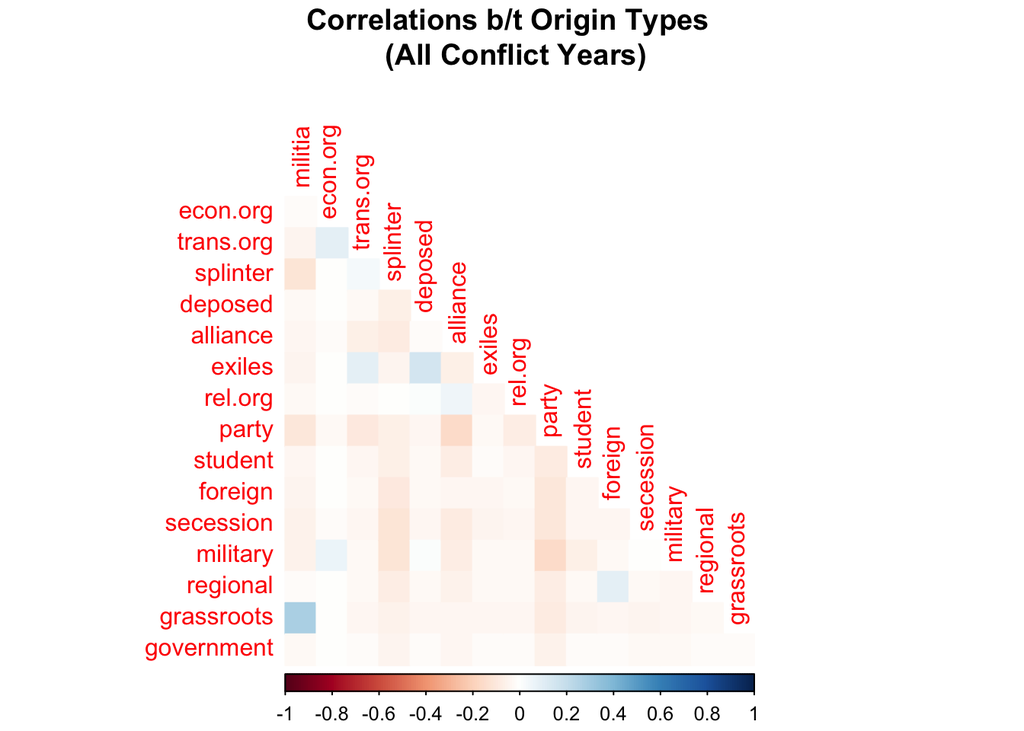

```r
library(corrplot)

cors <- subset(dyad, select=c(SideBID,Year,ConflictId,ConflictEpisode,origin,rebs.year,rebs.ep))

cors1 <- cors %>%
  group_by(ConflictId, Year) %>%
  summarize(militia=sum(origin=="militia", na.rm=T),  econ.org=sum(origin=="economic organization", na.rm=T), trans.org=sum(origin=="transnational organization", na.rm=T), splinter=sum(origin=="splinter", na.rm=T), deposed=sum(origin=="deposed government", na.rm=T), alliance=sum(origin=="alliance", na.rm=T), exiles=sum(origin=="exiles/diaspora", na.rm=T), rel.org=sum(origin=="religious organization", na.rm=T), party=sum(origin=="political party", na.rm=T), student=sum(origin=="student organization", na.rm=T), foreign=sum(origin=="foreign intervention", na.rm=T), secession=sum(origin=="secessionist organization", na.rm=T), military=sum(origin=="military faction", na.rm=T), regional=sum(origin=="regional government", na.rm=T), grassroots=sum(origin=="grassroots", na.rm=T), government=sum(origin=="government faction", na.rm=T))

cors1 <- cor(cors1[,3:18])

corrplot(cors1, method="color", type="lower", diag=F, mar=c(0,0,2.5,0), title = "Correlations b/t Origin Types \n (All Conflict Years)")
```

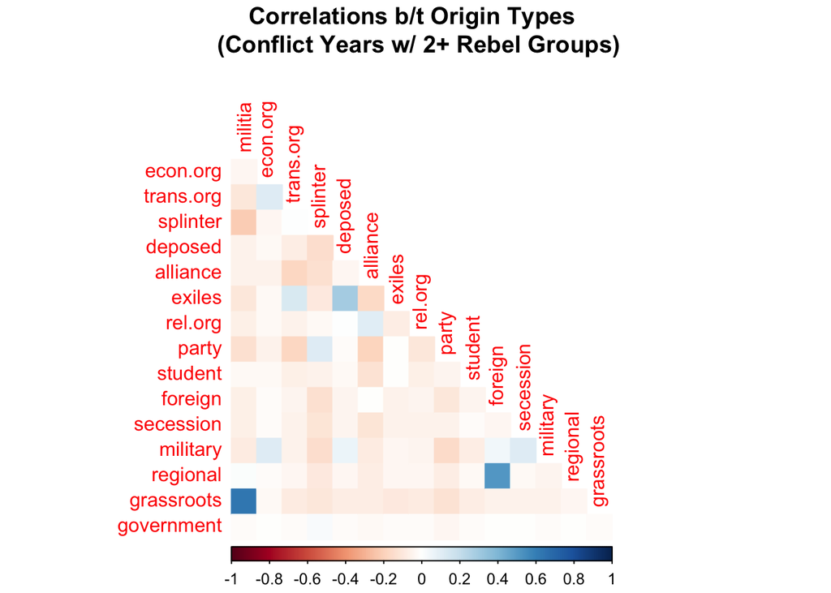

```r
#with only multi-rebel years
cors2 <- subset(cors, rebs.year>1) %>%
  group_by(ConflictId, Year) %>%
  summarize(militia=sum(origin=="militia", na.rm=T),  econ.org=sum(origin=="economic organization", na.rm=T), trans.org=sum(origin=="transnational organization", na.rm=T), splinter=sum(origin=="splinter", na.rm=T), deposed=sum(origin=="deposed government", na.rm=T), alliance=sum(origin=="alliance", na.rm=T), exiles=sum(origin=="exiles/diaspora", na.rm=T), rel.org=sum(origin=="religious organization", na.rm=T), party=sum(origin=="political party", na.rm=T), student=sum(origin=="student organization", na.rm=T), foreign=sum(origin=="foreign intervention", na.rm=T), secession=sum(origin=="secessionist organization", na.rm=T), military=sum(origin=="military faction", na.rm=T), regional=sum(origin=="regional government", na.rm=T), grassroots=sum(origin=="grassroots", na.rm=T), government=sum(origin=="government faction", na.rm=T))

cors2 <- cor(cors2[,3:18])

corrplot(cors2, method="color", type="lower", diag=F, mar=c(0,0,2.5,0), title = "Correlations b/t Origin Types \n (Conflict Years w/ 2+ Rebel Groups)")
```

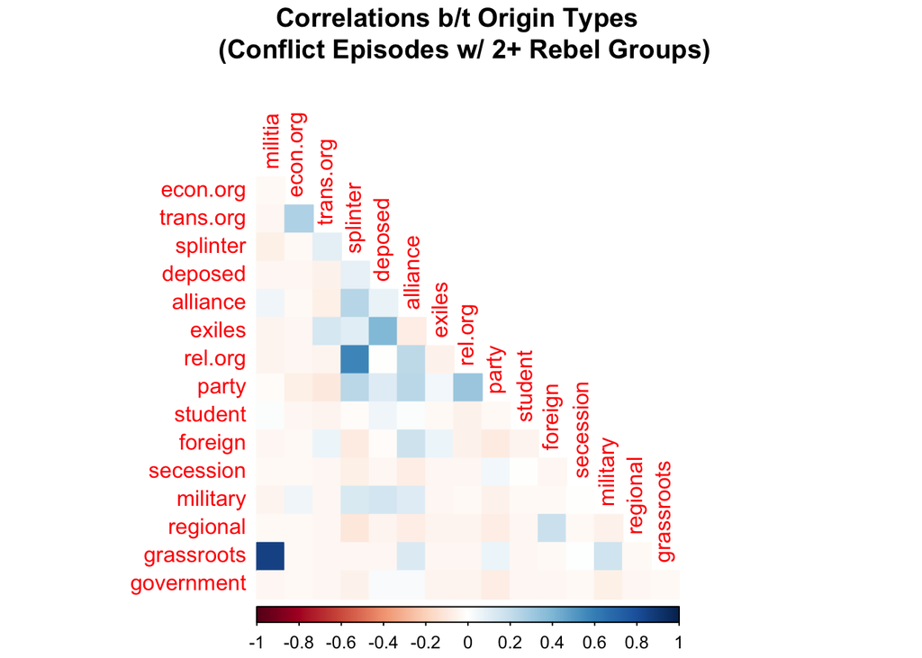

```r
#with only multi-rebel episodes
cors3 <- subset(cors, rebs.ep>1) %>%
  group_by(ConflictEpisode) %>%
  summarize(militia=sum(origin=="militia", na.rm=T),  econ.org=sum(origin=="economic organization", na.rm=T), trans.org=sum(origin=="transnational organization", na.rm=T), splinter=sum(origin=="splinter", na.rm=T), deposed=sum(origin=="deposed government", na.rm=T), alliance=sum(origin=="alliance", na.rm=T), exiles=sum(origin=="exiles/diaspora", na.rm=T), rel.org=sum(origin=="religious organization", na.rm=T), party=sum(origin=="political party", na.rm=T), student=sum(origin=="student organization", na.rm=T), foreign=sum(origin=="foreign intervention", na.rm=T), secession=sum(origin=="secessionist organization", na.rm=T), military=sum(origin=="military faction", na.rm=T), regional=sum(origin=="regional government", na.rm=T), grassroots=sum(origin=="grassroots", na.rm=T), government=sum(origin=="government faction", na.rm=T))

cors3 <- cor(cors3[,2:17])

corrplot(cors3, method="color", type="lower", diag=F, mar=c(0,0,2.5,0), title = "Correlations b/t Origin Types \n (Conflict Episodes w/ 2+ Rebel Groups)")
```

```r
rm(cors,cors1,cors2,cors3)
```